# R2

Predicting Diabetes in Pima Indian Population

Meghana Tatineni

02/19/2019

### Introduction to Machine Learning in R

```r
#install.packages(c("dplyr","ggplot2","caret","reshape","kernlab"))
#Data Manipulation
library(dplyr)
#Visulization
library(ggplot2)
#Machine Learning
library(caret)
#Data Manipulation
library(reshape)
#Machine Learning
library(kernlab)
```

The dataset is originally from National Institute of Diabetes and Digestive and Kidney Diseases. The purpose of the dataset is to diagnostically predict whether or not a patient has diabetes, based on certain diagnostic measurements included in the dataset. This datset is restricted to females at least 21 years old of Pima Indian heritage.

```r
#Read in Data
#Set Working Directory
diab<-read.csv("diabetes.csv")
```

# Exploratory Data Analysis

After loading our data, we are performing Exploratory Data Analysis to get a sense of what we are working with and how much data cleansing and wrangling we have to do. Usually 80% of the data science work is preparing the data for analysis and 20% is modeling our data. Thankfully, this data set is already clean so we won’t be doing much data prep. This will never be the case when working on a real data science project.

```r
#Looking at Data
head(diab)
```

```
##   Pregnancies Glucose BloodPressure SkinThickness Insulin  BMI
## 1           6     148            72            35       0 33.6
## 2           1      85            66            29       0 26.6
## 3           8     183            64             0       0 23.3
## 4           1      89            66            23      94 28.1
## 5           0     137            40            35     168 43.1
## 6           5     116            74             0       0 25.6
##   DiabetesPedigreeFunction Age Outcome
## 1                    0.627  50       1
## 2                    0.351  31       0
## 3                    0.672  32       1
## 4                    0.167  21       0
## 5                    2.288  33       1
## 6                    0.201  30       0
```

```r
str(diab)
```

```
## 'data.frame':    768 obs. of  9 variables:
##  $ Pregnancies             : int  6 1 8 1 0 5 3 10 2 8 ...
##  $ Glucose                 : int  148 85 183 89 137 116 78 115 197 125 ...
##  $ BloodPressure           : int  72 66 64 66 40 74 50 0 70 96 ...
##  $ SkinThickness           : int  35 29 0 23 35 0 32 0 45 0 ...
##  $ Insulin                 : int  0 0 0 94 168 0 88 0 543 0 ...
##  $ BMI                     : num  33.6 26.6 23.3 28.1 43.1 25.6 31 35.3 30.5 0 ...
##  $ DiabetesPedigreeFunction: num  0.627 0.351 0.672 0.167 2.288 ...
##  $ Age                     : int  50 31 32 21 33 30 26 29 53 54 ...
##  $ Outcome                 : int  1 0 1 0 1 0 1 0 1 1 ...
```

```r
#Change Outcome to Factor
diab$Outcome<- as.factor(diab$Outcome)
#number of missing values
sum(is.na.data.frame(diab))
```

```
## [1] 0
```

```r
#number of 0 values
colSums(diab == 0)
```

```
##              Pregnancies                  Glucose            BloodPressure
##                      111                        5                       35
##            SkinThickness                  Insulin                      BMI
##                      227                      374                       11
## DiabetesPedigreeFunction                      Age                  Outcome
##                        0                        0                      500
```

```r
colSums(diab == 0)/768
```

```
##              Pregnancies                  Glucose            BloodPressure
##              0.144531250              0.006510417              0.045572917
##            SkinThickness                  Insulin                      BMI
##              0.295572917              0.486979167              0.014322917
## DiabetesPedigreeFunction                      Age                  Outcome
##              0.000000000              0.000000000              0.651041667
```

# Cleaning Data

Since over 40% of the variable Insulin and 30% of SkinThickness is missing, we will remove these varibles from our dataset. We are also going to replace the 0 values with NA.

```r
#Replace 0 with NA
#remove Insulin and Skin Thickness
diab<- diab  %>% select(-Insulin, -SkinThickness) %>%
  mutate_each(funs(replace(.,.==0,NA)),-Outcome,-Pregnancies)
```

## Imputation with mean

To deal with the zero values, we will use Imputation.Imputation is just replacing missing values with substituted values.We will replace the missing values with the mean of each feature.

Read more here:https://towardsdatascience.com/how-to-handle-missing-data-8646b18db0d4

```r
#Replace missing values with Mean
for(i in 1:5) {
  diab[is.na(diab[,i]),i] <- mean(diab[,i], na.rm = T)
}
```

# Lets do some Visualization!

Now that we fixed the missing values, lets graph the distributions of all variables for diabetics and non diabetics.

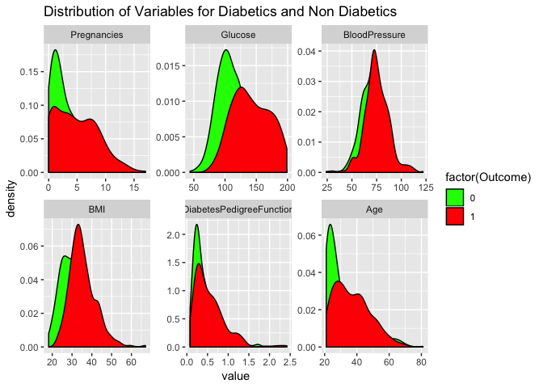

```r
#Distribution for All Variables
library(ggplot2)
library(reshape)
diab_melt<-melt(diab,id.vars = "Outcome")
ggplot(diab_melt, aes(value,fill=factor(Outcome)))+
  facet_wrap(~variable, scales="free") +
  geom_density()+
  scale_fill_manual(values=c("green", "red")) +
  labs(title="Distribution of Variables for Diabetics and Non Diabetics")
```

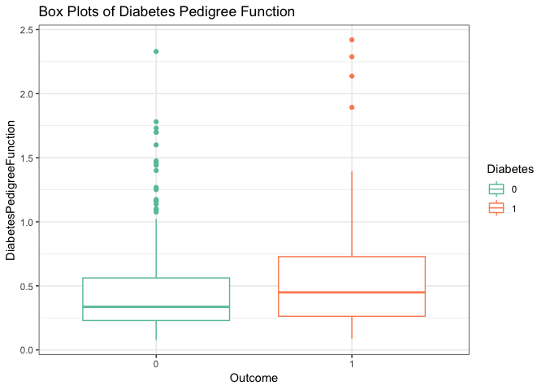

```r
#Box Plot
ggplot(diab, aes(x=Outcome, y=DiabetesPedigreeFunction,color=Outcome))+
  geom_boxplot()+
  theme_bw()+
  scale_colour_brewer(palette = "Set2",name = "Diabetes")+
  labs(title="Box Plots of Diabetes Pedigree Function")
```

# Lets Start Modeling

Before we start modeling, we need to split our data into a testing and training set.The purpose of this is to prevent overfitting. Here we are randomly splitting our data into 75% traning set and 25% testing set. We use the training set to train our model and the testing set to determine the accuracy of the model.

```r
#Simple Train and Test Split
library(caret)
train.rows<- createDataPartition(y= diab$Outcome, p=0.75, list = FALSE)
train<- diab[train.rows,]
test<- diab[-train.rows,]
```

We can finally start the modeling our data using statistical methods and machine learning!

## Logistic Regression

Logistic regression is a simple statistical model which predicts a binary response (ex.YES/NO). For this data, we are predicting whether a woman is diabetic or not.

Read more here:https://towardsdatascience.com/logistic-regression-detailed-overview-46c4da4303bc

```r
fit_log<-glm(train$Outcome~BMI+Glucose+Pregnancies, data=train, family="binomial")
summary(fit_log)
```

```
##
## Call:
## glm(formula = train$Outcome ~ BMI + Glucose + Pregnancies, family = "binomial",
##     data = train)
##
## Deviance Residuals:
##     Min       1Q   Median       3Q      Max
## -2.3001  -0.7251  -0.3997   0.7363   2.3220
##
## Coefficients:
##              Estimate Std. Error z value Pr(>|z|)
## (Intercept) -9.276670   0.815670 -11.373  < 2e-16 ***
## BMI          0.113705   0.017643   6.445 1.16e-10 ***
## Glucose      0.035460   0.003966   8.942  < 2e-16 ***
## Pregnancies  0.120009   0.032597   3.682 0.000232 ***
## ---
## Signif. codes:  0 '***' 0.001 '**' 0.01 '*' 0.05 '.' 0.1 ' ' 1
##
## (Dispersion parameter for binomial family taken to be 1)
##
##     Null deviance: 745.11  on 575  degrees of freedom
## Residual deviance: 540.80  on 572  degrees of freedom
## AIC: 548.8
##
## Number of Fisher Scoring iterations: 5
```

```r
predict_log<-predict(fit_log, test, type="response")
predict_log1<-as.factor(ifelse(predict_log <.5, "0","1"))
confusionMatrix(data = predict_log1, reference = test$Outcome, positive = "1",
                dnn = c("Algorithm predicted values", "Actual Test Values"))
```

```
## Confusion Matrix and Statistics
##
##                           Actual Test Values
## Algorithm predicted values   0   1
##                          0 108  26
##                          1  17  41
##
##                Accuracy : 0.776
##                  95% CI : (0.7104, 0.8329)
##     No Information Rate : 0.651
##     P-Value [Acc > NIR] : 0.0001183
##
##                   Kappa : 0.4912
##  Mcnemar's Test P-Value : 0.2224692
##
##             Sensitivity : 0.6119
##             Specificity : 0.8640
##          Pos Pred Value : 0.7069
##          Neg Pred Value : 0.8060
##              Prevalence : 0.3490
##          Detection Rate : 0.2135
##    Detection Prevalence : 0.3021
##       Balanced Accuracy : 0.7380
##
##        'Positive' Class : 1
##
```

## K-nearest neighbors

For each test data point, we would be looking at the K nearest training data points and take the most frequently occurring classes and assign that class to the test data.

Read more here:https://medium.com/@adi.bronshtein/a-quick-introduction-to-k-nearest-neighbors-algorithm-62214cea29c7

```r
knnFit<-train(Outcome~BMI+Glucose+Pregnancies, data=train, method="knn",
              preProcess=c("center","scale"))
predict_data<-predict(knnFit, newdata=test)
confusionMatrix(data = predict_data, reference = test$Outcome, positive = "1",
                dnn = c("Algorithm predicted values", "Actual Test Values"))
```

```
## Confusion Matrix and Statistics
##
##                           Actual Test Values
## Algorithm predicted values   0   1
##                          0 100  22
##                          1  25  45
##
##                Accuracy : 0.7552
##                  95% CI : (0.6881, 0.8143)
##     No Information Rate : 0.651
##     P-Value [Acc > NIR] : 0.001235
##
##                   Kappa : 0.4668
##  Mcnemar's Test P-Value : 0.770493
##
##             Sensitivity : 0.6716
##             Specificity : 0.8000
##          Pos Pred Value : 0.6429
##          Neg Pred Value : 0.8197
##              Prevalence : 0.3490
##          Detection Rate : 0.2344
##    Detection Prevalence : 0.3646
##       Balanced Accuracy : 0.7358
##
##        'Positive' Class : 1
##
```

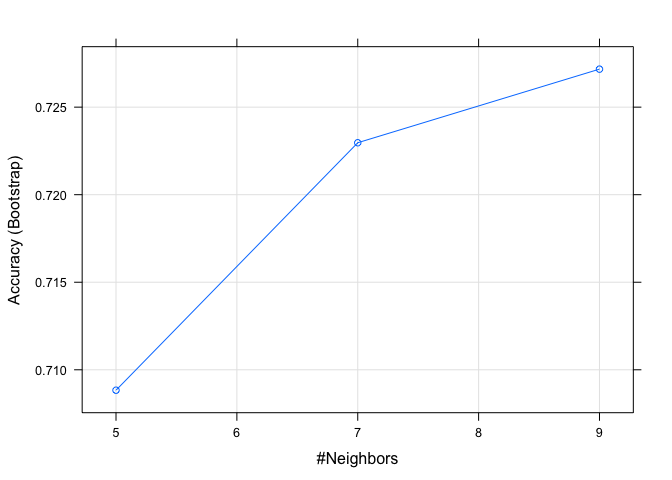

```r
#plotting different number of neighbors and accuracy
plot(knnFit)
```

## Support Vector Machine

Support vector machines attempt to pass a linearly separable hyperplane through a dataset to classify the data into two groups.

Read more here:https://towardsdatascience.com/support-vector-machines-a-brief-overview-37e018ae310f

```r
svmfit<-train(Outcome~BMI+Glucose+Pregnancies, data=train, method="svmLinear",
              preProcess=c("center","scale"))
predict_data<-predict(svmfit, newdata=test)
confusionMatrix(data = predict_data, reference = test$Outcome,
                dnn = c("Algorithm predicted values", "Actual Test Values"))
```

```
## Confusion Matrix and Statistics
##
##                           Actual Test Values
## Algorithm predicted values   0   1
##                          0 108  27
##                          1  17  40
##
##                Accuracy : 0.7708
##                  95% CI : (0.7048, 0.8283)
##     No Information Rate : 0.651
##     P-Value [Acc > NIR] : 0.0002216
##
##                   Kappa : 0.4776
##  Mcnemar's Test P-Value : 0.1748444
##
##             Sensitivity : 0.8640
##             Specificity : 0.5970
##          Pos Pred Value : 0.8000
##          Neg Pred Value : 0.7018
##              Prevalence : 0.6510
##          Detection Rate : 0.5625
##    Detection Prevalence : 0.7031
##       Balanced Accuracy : 0.7305
##
##        'Positive' Class : 0
##
```

```r
#Tuning Paramter c with Grid Search
grid <- expand.grid(C = c(0.01,0.1,0.5, 0.75, 1, 1.5, 1.75, 2,5))
svm_Linear_Grid <- train(Outcome ~., data = train, method = "svmLinear",
                           preProcess = c("center", "scale"),
                           tuneGrid = grid)
svm_Linear_Grid
```

```
## Support Vector Machines with Linear Kernel
##
## 576 samples
##   6 predictor
##   2 classes: '0', '1'
##
## Pre-processing: centered (6), scaled (6)
## Resampling: Bootstrapped (25 reps)
## Summary of sample sizes: 576, 576, 576, 576, 576, 576, ...
## Resampling results across tuning parameters:
##
##   C     Accuracy   Kappa
##   0.01  0.7723559  0.4510140
##   0.10  0.7727495  0.4652853
##   0.50  0.7724287  0.4673078
##   0.75  0.7727984  0.4684634
##   1.00  0.7726218  0.4678846
##   1.50  0.7724519  0.4676467
##   1.75  0.7718493  0.4665505
##   2.00  0.7718396  0.4666305
##   5.00  0.7722605  0.4680404
##
## Accuracy was used to select the optimal model using the largest value.
## The final value used for the model was C = 0.75.
```

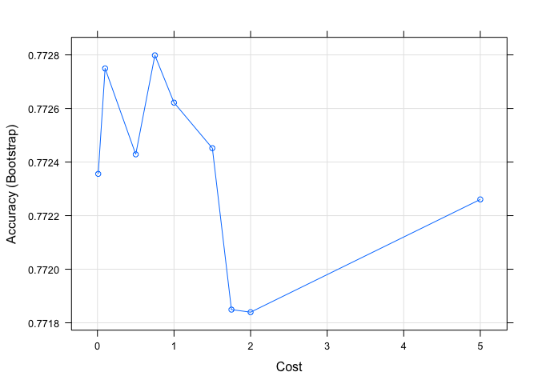

```r
plot(svm_Linear_Grid)
```

To increase our classification rate, we can try tuning our parameters for each classification algorithm and try other classification algorithms such as random forests and neural networks.